# Ecological & Evolutionary Biogeography Day 1: Intro to R

[Maia Kapur](http://www.maiarkapur.wordpress.com)

28 Nov 2016 - Barcelona, Spain

## PART I: R STUDIO TOUR

#### [Click here to check out Lasting Data Analysis (pdf)](https://drive.google.com/file/d/0B0goXsJkrNrGOXFpbDA4TjM3X2c/view?usp=sharing) - a short guide to good data management and coding practices.

[Here’s a link](http://phylo.wikidot.com/transsci#toc0) to Nick Matzke’s R tutorial (it’s buried within the Intro to ML/Phylogenies) online. He was supposed to teach this course but missed his flight.

#### Functions - just a brief overview here. See Part IV for writing functions.

```r
## A function is a little machine. The input goes in parentheses:
seq(1,10)
```

```
 [1]  1  2  3  4  5  6  7  8  9 10
```

```r
print('hello')
```

```
[1] "hello"
```

```r
    ## > this symbol means a new line of code
    ## + this means that R is waiting for you to say something. Typically you will forget to add a close-parentheses, hit enter, and the little plus will show up. You can either add in whatever you were missing, or hit ESC to get the ">" back.
```

#### Packages - for more functions

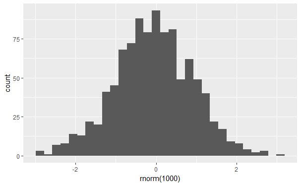

```r
#' Install using install.packages("packageName"). Load these using library(packageName) -- You must already have these installed to load, which you can check out using the 'Packages' tab in the bottom-right hand window.
library(ggplot2) ## loads the ggplot2 which is full of functions that someone else wrote. This is a great data visualization package.
qplot(rnorm(1000))
```

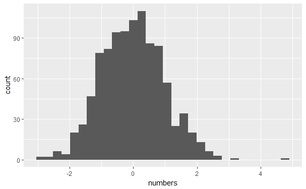

```r
## This builds in a qplot (quick histogram plot) of the result of rnorm(1000). Rnorm is a normal distribution generator, and the number you provide to rnorm indicates how many numbers you want to generate. You can also do this in two separate steps:
numbers <- rnorm(1000)
qplot(numbers)
```

```r
## runif(1000) is a similar function that produces a UNIForm distribution as opposed to a NORMal one.
```

#### Help Files - should be provided for every package/function in R

##### In RStudio you can use the tab keys after writing a function to remind yourself what you can put into that function. Another tip is to type a question mark before the function’s name which will pop up the HELP window in the bottom-right. In the window, you’ll see each term that the function will accept, and a quasi-informative description of how that input was designed when someone created it. Scroll dow and it should tell you what each argument (input) means.

```r
?rnorm
help(rnorm) ## does the same thing
??rnorm ## double question marks will do a "search" for functions that contain that term - useful if you don't know the name of the function exactly.
## In the console window, put the mouse cursor on the function (e.g. "source") and hit F1 to get help
```

## PART II: ASSIGNING VARIABLES AND CLASSES

#### Variables: A small piece of information, assigned using the = or <- symbols. Once you assign a variable, they should pop up in your environment tab. Technically, the <- symbol is the assignment operator, and there are many who feel this is superior to the equals sign. In general, it avoids confusion. Don’t confuse = with ==. The latter asks “is equal to?”

```r
x = 8
x == 9
```

```
[1] FALSE
```

```r
y <- 10
x + y
```

```
[1] 18
```

```r
## Running the above function does not change the value of x or y. You could change this as follows
x = x + y
## Now x is 18, and you've overwritten the previous instance of x as 8.
## The function objects() will return whatever is in your environment tab into the console for you to check out.
```

#### The class is the ‘type’ of your variable.

##### You can find out what type (class) your variable is by using the class() function. This is important because certain functions will only accept given classes, for example, you can’t add together two words (class character) class(x) should return numeric.In this mini-example, you’ve tricked R into thinking that T is the number 4, then you later ask if 3 ‘is equal to’ T, for which it returns F (correctly). But if later you wanted to find out if a column of data had T or F (say, from a survey), you’d be in trouble, since R wouldn’t be reading in ‘T’ as TRUE, but as the number 4!! In general, if you mess this up, use rm() to remove whatever you’ve done. **When you first start out, class errors will account for many code breaks. Make sure you’re feeding functions the right type of data and/or variables, otherwise you’ll get an error**.

```r
x = 'super classy'
y = 10

class(x) ## will be character (meaning letters).
attributes(x) ## will return the class and its name (e.g. "superclassy"

## Boolean: T/F. You can indicate these using T or TRUE (all caps); or F or FALSE. These are important, logical statements, and for this reason you can/should NOT assign a variable to either of these terms.
x = 'super'
y = 10
class(x)
T = F
T
T = 4
T
4 == T
3 == T
rm(T)
T
x = c(7,5,4,8,3,1)
class(x)
length(x)
x*10
length(x) == 2
max(x)
sd(x)
x[3]
x[2:4]
x[c(2,5,6)]
## a slow way to do the above
wanted = c(2,5,6)
x[wanted]
```

#### Working with vectors and naming columns.

```r
## c() is how you concatenate together a bunch of things, like numbers, to create a vector.
x = c(7,5,4,8,3,1)
class(x)
length(x)
x*10
length(x) == 2
y <- c('oh', 'lordy', 'I', 'do', 'love', 'vectors') ## a vector of words
y[c(1,4,3,5,6)] ## select individual members and print them in order
## the names() function makes the names of the columns
names(y) = c("eeny","meeny","hermione","moe","catch","a")

## view certain columns-- this helps you call them by name instead of memorizing which number is which.
y[c('eeny')]
```

#### Multi-dimensional data - more indexing in matrices.

```r
## creating a matrix - you won't do this too often
col1 = c(1,2,3)
col2 = c(4,5,6)
col3 <- c(7,8,9)
x = cbind(col1,col2,col3) ## uses the Cbind function to bind by columns.
x
y = cbind(col1,col2,col3)
y
x[2,3] ## retrives the element in row 2, column 3

x[3,c(1,3)] ## retrieves row 3, columns one and three. To break this down
x[2,2]/x[3,3] ## divide choice elements
x[2,1:3] ## retrieve row two, columns 1,2,3
x[2,] ## just row 2
x[,3] ## just col 3
rownames(x) = c('r1','r2','r3')
x['r2','col3']
x[,3] * 5 ## this will tell you what happens when column 3 of x is multiplied by 5
x[,3] <- x[,3] * 5 ## this ACTUALLY changes column three to be multiplied by 5. nothing really changes until you do the assignment.
```

## PART III: DATA FRAMES

#### **A matrix has to have only one class within it – you can’t have a mix of class(character) and class (numeric) – but you can have both letters and numbers in a data frame. If you DO concactenate letters and numbers into a matrix, it will just coerce everything to the same class, typically character. This is undesirable, so we work with data frames. See below**.

```r
col1 = c(1,2,3) ## numeric
col2 = c('cheese','pickles','tomato') ## characters
col3 = c(FALSE, TRUE, TRUE) ## booleans
x = data.frame(num.eaten = col1, ingredient = col2, is.vegan = col3) ## this assigns the column names inside of it, you could also do this separately using (names) afterwards
```

#### Accessing columns in a data frame

```r
## the $ operator picks up a column, You can also use this to assign columns on the fly.
x$calories = c(200,25,30)
y$calories = x$calories
```

```
Coercing LHS to a list
```

```r
require(ggplot2)
```

#### Loading in the Coffee dataset (from the course Dropbox)

```r
setwd('C:/Users/M Kapur/Downloads/') ## the path to whereve you save stuff -- this becomes your default
```

[output not shown]

```r
list.files() ## will tell you what's in there
```

```
 [1] "16.40.2802-whql-308234c-hpmobile.zip"
 [2] "ab.syllabus+_online_.docx"
 [3] "bayesian_modelling_guide.pdf"
 [4] "bhm_course-master.zip"
 [5] "coffee.csv"
 [6] "desktop.ini"
 [7] "GitHubSetup.exe"
 [8] "iberoc.txt"
 [9] "iberoc.zip"
[10] "iberolacerta.clade.Rd"
[11] "IMG_1817.JPG"
[12] "JAGS-4.2.0-Rtools33.exe"
[13] "JAGS-4.2.0.html"
[14] "Lasting Data Analysis.pdf"
[15] "Photo Apr 04, 9 46 50 AM.jpg"
[16] "Photo Apr 21, 11 36 47 AM.jpg"
[17] "Photo Aug 11, 7 53 34 AM (1).jpg"
[18] "Photo Feb 05, 9 35 44 PM (1).jpg"
[19] "Photo Feb 16, 5 46 51 PM.jpg"
[20] "Photo Jan 01, 10 42 13 AM.jpg"
[21] "Photo Jan 31, 2 59 01 PM (1).jpg"
[22] "Photo Jun 15, 1 39 47 PM.jpg"
[23] "R-3.3.2-win.exe"
[24] "RStudio-1.0.39.exe"
[25] "RStudio-1.0.44.exe"
[26] "Rtools33.exe"
[27] "sp77117.exe"
[28] "sp77789.exe"
[29] "states_21basic.zip"
```

```r
list.files(pattern = '.csv') ## will just show files that fit this pattern
```

```
[1] "coffee.csv"
```

```r
coffee.df = read.csv('C:/Users/M Kapur/Downloads/coffee.csv') ## read in the file -- you'll get an error if it's not in your working directory as specified above
head(coffee.df) ## top 6 rows
```

|  | score | coffee | awake | breaks | teacher | gender |
| --- | --- | --- | --- | --- | --- | --- |
| 1 | 60 | 97.77858 | 1 | 1 | G | F |
| 2 | 37 | 25.44362 | 0 | 0 | F | M |
| 3 | 83 | 0.00000 | 0 | 0 | C | F |
| 4 | 36 | 111.34397 | 1 | 1 | F | M |
| 5 | 99 | 57.07678 | 1 | 0 | A | F |
| 6 | 95 | 74.30035 | 1 | 1 | C | F |

```r
tail(coffee.df) ## bottom 6
```

|  | score | coffee | awake | breaks | teacher | gender |
| --- | --- | --- | --- | --- | --- | --- |
| 95 | 71 | 78.24430 | 1 | 0 | B | M |
| 96 | 94 | 90.75200 | 1 | 1 | C | F |
| 97 | 25 | 119.00695 | 1 | 2 | J | F |
| 98 | 87 | 100.04480 | 1 | 1 | A | M |
| 99 | 92 | 85.48799 | 1 | 1 | C | M |
| 100 | 24 | 86.44614 | 1 | 3 | J | F |

```r
head(coffee.df, n = 15) ## top 15 rows
```

|  | score | coffee | awake | breaks | teacher | gender |
| --- | --- | --- | --- | --- | --- | --- |
| 1 | 60 | 97.77858 | 1 | 1 | G | F |
| 2 | 37 | 25.44362 | 0 | 0 | F | M |
| 3 | 83 | 0.00000 | 0 | 0 | C | F |
| 4 | 36 | 111.34397 | 1 | 1 | F | M |
| 5 | 99 | 57.07678 | 1 | 0 | A | F |
| 6 | 95 | 74.30035 | 1 | 1 | C | F |
| 7 | 32 | 76.62088 | 1 | 1 | J | F |
| 8 | 77 | 146.37646 | 1 | 0 | B | M |
| 9 | 46 | 142.55265 | 1 | 5 | D | F |
| 10 | 59 | 71.01984 | 1 | 0 | B | M |

[output cut: 5 more lines]

```r
str(coffee.df) ## structure of df - shows your columns, what sort of data is in it, and a preview.
```

```
'data.frame':   100 obs. of  6 variables:
 $ score  : int  60 37 83 36 99 95 32 77 46 59 ...
 $ coffee : num  97.8 25.4 0 111.3 57.1 ...
 $ awake  : int  1 0 0 1 1 1 1 1 1 1 ...
 $ breaks : int  1 0 0 1 0 1 1 0 5 0 ...
 $ teacher: Factor w/ 10 levels "A","B","C","D",..: 7 6 3 6 1 3 10 2 4 2 ...
 $ gender : Factor w/ 2 levels "F","M": 1 2 1 2 1 1 1 2 1 2 ...
```

```r
summary(coffee.df) ## numerical summary of dataframe
```

```
     score            coffee           awake          breaks
 Min.   : 23.00   Min.   :  0.00   Min.   :0.00   Min.   :0.00
 1st Qu.: 51.75   1st Qu.: 62.01   1st Qu.:0.00   1st Qu.:0.00
 Median : 68.00   Median : 93.47   Median :1.00   Median :1.00
 Mean   : 69.34   Mean   : 89.72   Mean   :0.68   Mean   :1.14
 3rd Qu.: 94.25   3rd Qu.:121.60   3rd Qu.:1.00   3rd Qu.:2.00
 Max.   :100.00   Max.   :202.87   Max.   :1.00   Max.   :7.00

    teacher   gender
 A      :10   F:51
 B      :10   M:49
 C      :10
 D      :10
 E      :10
 F      :10
 (Other):40
```

```r
coffee.df$gender  == 'F' ## show me rows where gender is Female
```

```
  [1]  TRUE FALSE  TRUE FALSE  TRUE  TRUE  TRUE FALSE  TRUE FALSE FALSE
 [12] FALSE  TRUE FALSE FALSE  TRUE FALSE FALSE  TRUE  TRUE  TRUE  TRUE
 [23]  TRUE FALSE FALSE FALSE  TRUE FALSE FALSE  TRUE  TRUE FALSE FALSE
 [34]  TRUE  TRUE FALSE FALSE  TRUE FALSE  TRUE FALSE FALSE FALSE FALSE
 [45]  TRUE FALSE  TRUE  TRUE  TRUE  TRUE  TRUE  TRUE FALSE  TRUE  TRUE
 [56]  TRUE FALSE  TRUE FALSE  TRUE FALSE  TRUE FALSE FALSE  TRUE FALSE
 [67] FALSE  TRUE  TRUE  TRUE FALSE  TRUE FALSE  TRUE  TRUE  TRUE FALSE
 [78] FALSE FALSE FALSE FALSE  TRUE FALSE FALSE  TRUE FALSE  TRUE  TRUE
 [89] FALSE FALSE  TRUE  TRUE  TRUE FALSE FALSE  TRUE  TRUE FALSE FALSE
[100]  TRUE
```

```r
coffee.df[coffee.df[,'gender']  == 'F',] ## show me rows where gender equals female, and all associated columns
```

|  | score | coffee | awake | breaks | teacher | gender |
| --- | --- | --- | --- | --- | --- | --- |
| 1 | 60 | 97.77858 | 1 | 1 | G | F |
| 3 | 83 | 0.00000 | 0 | 0 | C | F |
| 5 | 99 | 57.07678 | 1 | 0 | A | F |
| 6 | 95 | 74.30035 | 1 | 1 | C | F |
| 7 | 32 | 76.62088 | 1 | 1 | J | F |
| 9 | 46 | 142.55265 | 1 | 5 | D | F |
| 13 | 68 | 84.12764 | 0 | 1 | I | F |
| 16 | 34 | 129.90812 | 1 | 1 | J | F |
| 19 | 55 | 93.37102 | 0 | 0 | D | F |
| 20 | 83 | 123.00231 | 1 | 2 | E | F |

[output cut: 41 more lines]

```r
coffee.df[coffee.df[,'gender'] == 'M',c('coffee','awake')] ## takes out just the men and then returns columns coffee and awake
```

|  | coffee | awake |
| --- | --- | --- |
| 2 | 25.44362 | 0 |
| 4 | 111.34397 | 1 |
| 8 | 146.37646 | 1 |
| 10 | 71.01984 | 1 |
| 11 | 82.34519 | 0 |
| 12 | 101.23664 | 1 |
| 14 | 147.92229 | 1 |
| 15 | 56.94513 | 1 |
| 17 | 120.36562 | 0 |
| 18 | 90.51499 | 1 |

[output cut: 39 more lines]

```r
## create a new data frame with only female participants from coffee.df, then make a new df from that which only had teacher A
## using square indices
fems = coffee.df[coffee.df[,'gender'] == 'F',]
fems
```

|  | score | coffee | awake | breaks | teacher | gender |
| --- | --- | --- | --- | --- | --- | --- |
| 1 | 60 | 97.77858 | 1 | 1 | G | F |
| 3 | 83 | 0.00000 | 0 | 0 | C | F |
| 5 | 99 | 57.07678 | 1 | 0 | A | F |
| 6 | 95 | 74.30035 | 1 | 1 | C | F |
| 7 | 32 | 76.62088 | 1 | 1 | J | F |
| 9 | 46 | 142.55265 | 1 | 5 | D | F |
| 13 | 68 | 84.12764 | 0 | 1 | I | F |
| 16 | 34 | 129.90812 | 1 | 1 | J | F |
| 19 | 55 | 93.37102 | 0 | 0 | D | F |
| 20 | 83 | 123.00231 | 1 | 2 | E | F |

[output cut: 41 more lines]

```r
teachA.fems = fems[fems[,'teacher'] == 'A',]
teachA.fems
```

|  | score | coffee | awake | breaks | teacher | gender |
| --- | --- | --- | --- | --- | --- | --- |
| 5 | 99 | 57.07678 | 1 | 0 | A | F |
| 27 | 100 | 109.49552 | 1 | 1 | A | F |
| 30 | 100 | 143.52073 | 1 | 5 | A | F |
| 49 | 100 | 83.56453 | 1 | 1 | A | F |
| 69 | 100 | 97.60381 | 1 | 1 | A | F |

```r
## using dollar signs
fems2 = coffee.df[coffee.df$gender == 'F',]
teachA.fems2 = fems2[fems$teacher == 'A',]
## using subset() function
fems3 = subset(coffee.df, gender == 'F')
teachA.fems3 = subset(fems, teacher == 'A')
## all in one with indices and subset
coffee.df[coffee.df[,'gender'] == 'F' & coffee.df[,'teacher'] == 'A',]
```

|  | score | coffee | awake | breaks | teacher | gender |
| --- | --- | --- | --- | --- | --- | --- |
| 5 | 99 | 57.07678 | 1 | 0 | A | F |
| 27 | 100 | 109.49552 | 1 | 1 | A | F |
| 30 | 100 | 143.52073 | 1 | 5 | A | F |
| 49 | 100 | 83.56453 | 1 | 1 | A | F |
| 69 | 100 | 97.60381 | 1 | 1 | A | F |

```r
subset(coffee.df, gender == 'F' & teacher == 'A')
```

|  | score | coffee | awake | breaks | teacher | gender |
| --- | --- | --- | --- | --- | --- | --- |
| 5 | 99 | 57.07678 | 1 | 0 | A | F |
| 27 | 100 | 109.49552 | 1 | 1 | A | F |
| 30 | 100 | 143.52073 | 1 | 5 | A | F |
| 49 | 100 | 83.56453 | 1 | 1 | A | F |
| 69 | 100 | 97.60381 | 1 | 1 | A | F |

## PART IV: FUNCTIONS

#### Functions - a way to customize your own Data Factory. This can be used to automate lots of processes you’d otherwise have to replicate “by hand”.

```r
#' You declare a function using the function() call. What is in the parenthesis designates how many inputs it accepts, and what's in between the curly brackets does the actual procedure performed on those input(s)
my.function <- function(my.input){
  my.output = c(my.input, my.input)
  return(my.output)
}
## now that it's set up, we can run it like any other function:
my.function(4)
```

```
[1] 4 4
```

```r
my.function('doo-wop')
```

```
[1] "doo-wop" "doo-wop"
```

```r
## A pseudo-automator...you could nest and automate entire projects' worth of data processing!!
process.report <- function(my.data){
  ## fancy code running fancy things
  ## returns processed data
}
## write a function that returns twice whatever number you feed it.
two.times = function(input){ ## sets up the function and assigns it to "two.times"
  output = input*2 ## the 'meat' -- what we want to do to our input, save it as 'output'
  return(output) ## this line determines what gets spit out at the end of the function
}
## keep in mind that the variable names don't matter -- the word "input" could also be 'x'or 'Trump'
two.times(2.8937)
```

```
[1] 5.7874
```

```r
rm(ls)
```

```
object 'ls' not found
```

```r
add.three = function(x,y,z){
  return(x+y+z)
}
add.three(4,3,22) ## this will give you an error if you provide more or less than 3 inputs
```

```
[1] 29
```

#### Creating a function using the Attitude Dataset

```r
# require(GGally)
# require(ggplot2)
data(attitude) ## this is how you load in pre-existing data packages. There are dozens in R.
help(attitude) ## if you need help with your attitude ;)
head(attitude) ## view the top 6 rows
```

|  | rating | complaints | privileges | learning | raises | critical | advance |
| --- | --- | --- | --- | --- | --- | --- | --- |
| 1 | 43 | 51 | 30 | 39 | 61 | 92 | 45 |
| 2 | 63 | 64 | 51 | 54 | 63 | 73 | 47 |
| 3 | 71 | 70 | 68 | 69 | 76 | 86 | 48 |
| 4 | 61 | 63 | 45 | 47 | 54 | 84 | 35 |
| 5 | 81 | 78 | 56 | 66 | 71 | 83 | 47 |
| 6 | 43 | 55 | 49 | 44 | 54 | 49 | 34 |

```r
# ggpairs(attitude) ## shows plots of every variable against the others
## a function that gives the mean of each column (using pre-existing function colMeans), the maximum of the RATING column, and a simple plot of the relationship between RATING and COMPLAINT. Put the first two in a list to return
att.func = function(df){
  mns = colMeans(df)
  maxrat = max(df$rating)
  z = qplot(rating, complaints, data = df) ## there are several ways you can do this
  return(list(mns, maxrat, z)) ## this is what will get put out when you run the function
}
proc <- att.func(attitude) ## using the assignment will SAVE everything that came out of that function
no.input = function(){
  print('I got no input')
}
test = no.input()
```

```
[1] "I got no input"
```

```r
## don't do it
function.of.no.return <- function(x,y){
  x + y ## even though you didn't say 'return' it will still return the last thing you said
}
function.of.no.return(4,5)
```

```
[1] 9
```

```r
## slow-going function with each step broken down
x = 1:10
y = mean(x)
z = sd(x)
max(y,z) ## which is the highest value?
```

```
[1] 5.5
```

```r
## shortened. R evaluates functions from the inside-out
max(mean(x),sd(x))
```

```
[1] 5.5
```

```r
paste("The max is ", 2) ## just throws whatever you put in into a script. We can use this to summarize outputs. You can input functions in here & separate items with commas.
```

```
[1] "The max is  2"
```

```r
paste("The max is ",max(mean(x),sd(x)))
```

```
[1] "The max is  5.5"
```

## PART V. More functions with Ape.

[output not shown]

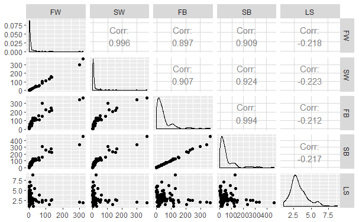

```r
#install.packages('ape')
library(ape)
require(GGally)
data("carnivora")
ggpairs(carnivora[,6:10]) ## the Species column has too many levels
```

```r
## get means of columns 6 thru 12, but only for Canids (family = Canidae)
## slow going methods
## with indexing
df0 <- carnivora[carnivora[,'Family'] == 'Canidae',]
colMeans(df0[,6:12])
```

```
       FW        SW        FB        SB        LS        GL        BW
 9.050000  9.511111 58.388889 59.455556  4.433333        NA        NA
```

```r
## with subset
df1 <- subset(carnivora, Family == 'Canidae')
colMeans(df1[,6:12])
```

```
       FW        SW        FB        SB        LS        GL        BW
 9.050000  9.511111 58.388889 59.455556  4.433333        NA        NA
```

```r
## shorthand - mixes together the indexing steps
colMeans(carnivora[carnivora[,'Family'] == 'Canidae',][,6:12])
```

```
       FW        SW        FB        SB        LS        GL        BW
 9.050000  9.511111 58.388889 59.455556  4.433333        NA        NA
```

```r
## Get the FAMILY for each species that has an average female body weight over 20 (this is given by column SW)
## using indices - two steps
## first take out the ones with the female body weight desired
highsw = carnivora[carnivora[,'SW'] > 20,]
## then view the family column of that subset
highsw[,c('Species','Family')]
```

|  | Species | Family |
| --- | --- | --- |
| 1 | Canis lupus | Canidae |
| 5 | Lycaon pictus | Canidae |
| 17 | Chrysocyon brachyurus | Canidae |
| 19 | Ursus arctos | Ursidae |
| 20 | Ursus americanus | Ursidae |
| 21 | Thalarctos maritimus | Ursidae |
| 22 | Selenarctos thibetanus | Ursidae |
| 27 | Ailuropoda melanoleuca | Ailuridae |
| 57 | Enhvdra lutris | Mustelidae |
| 90 | Hyaena hyaena | Hyaenidae |

[output cut: 9 more lines]

```r
## using indices - shorthand
carnivora[carnivora[,'SW'] > 20,c('Species','Family')]
```

|  | Species | Family |
| --- | --- | --- |
| 1 | Canis lupus | Canidae |
| 5 | Lycaon pictus | Canidae |
| 17 | Chrysocyon brachyurus | Canidae |
| 19 | Ursus arctos | Ursidae |
| 20 | Ursus americanus | Ursidae |
| 21 | Thalarctos maritimus | Ursidae |
| 22 | Selenarctos thibetanus | Ursidae |
| 27 | Ailuropoda melanoleuca | Ailuridae |
| 57 | Enhvdra lutris | Mustelidae |
| 90 | Hyaena hyaena | Hyaenidae |

[output cut: 9 more lines]

```r
## shorthand with unique() and subset()
unique(subset(carnivora, SW > 20)[,c('Species','Family')])
```

|  | Species | Family |
| --- | --- | --- |
| 1 | Canis lupus | Canidae |
| 5 | Lycaon pictus | Canidae |
| 17 | Chrysocyon brachyurus | Canidae |
| 19 | Ursus arctos | Ursidae |
| 20 | Ursus americanus | Ursidae |
| 21 | Thalarctos maritimus | Ursidae |
| 22 | Selenarctos thibetanus | Ursidae |
| 27 | Ailuropoda melanoleuca | Ailuridae |
| 57 | Enhvdra lutris | Mustelidae |
| 90 | Hyaena hyaena | Hyaenidae |

[output cut: 9 more lines]

## PART V.5 IF STATEMENTS

#### Here we’re leveraging the TRUES and FALSES. These look like functions, because they have curly brackets. Basically the if() function evaluates whatever is in parenthesis; if that returns TRUE, it does whatever’s inside the curlies. If the statement is FALSE, nothing happens OR you can tell it to do something ELSE with an ELSE statement.

```r
x = 4
if(x == 5){
  print("hooray!")
  } else {
    print('boo!')
  }
```

```
[1] "boo!"
```

```r
## change x and re-run it to change the outcome.
## write a function that takes two numbers & returns column means for columns between those two numbers (eg 3,6 would be columns 3 thru 6). But since there are only 17 columns, don't run this if one number is greater than 17 -- give an error.
pickmeans = function(n){
  if(n > 15){
    print('Sorry, your specified number is too high. Sincerly, Siri')
  } else{
    nums = colMeans(carnivora[,6:n])
    return(nums)
  }
}
pickmeans(27)
```

```
[1] "Sorry, your specified number is too high. Sincerly, Siri"
```

```r
pickmeans(7)
```

```
      FW       SW
18.09857 20.08429
```